# skat_wecare_only

started: Alexey Larionov, 27Mar2017  
last updated: Alexey Larionov, 30Aug2017

# Summary

SKAT cbc vs ubc (including matching information in the model), wecare only

Efficient Resampling (ER) is used because this is the most accurate (?) method for  
P-assessment from small counts in SKAT package (Lee et al Biostatistics 2016).  
However, Efficient Resampling may become computationally heavy for large numbers of samples.

is.accurate and MAP are only reported my resampling methods (ER or ER.A)  
so the script should be modified if used for method.bin = “Hybrid”

# start_section

```r
# Start time
Sys.time()
```

```
## [1] "2017-08-30 16:58:24 BST"
```

```r
# Clenan-up
rm(list=ls())

# Libraries location
.libPaths("/home/alarionov/R/my_libs_r3.4.1/")

# Base folder
library(knitr)
base_folder="/analysis/mtgroup_share/users/alexey/wecare_only_08.17"
opts_knit$set(root.dir = base_folder)
#setwd(base_folder)

# Libraries
library(SKAT)
```

# load_data

```r
#base_folder="/analysis/mtgroup_share/users/alexey/wecare_only_08.17"
load(paste(base_folder, "results", "r08_filter_by_inverted_af_wecare_only.RData", sep="/"))
```

# check_data

```r
dim(genotypes.mx)
```

```
## [1] 16809   478
```

```r
class(genotypes.mx)
```

```
## [1] "matrix"
```

```r
genotypes.mx[1:5,1:5]
```

```
##              P1_A01 P1_A02 P1_A03 P1_A04 P1_A05
## Var000000026      0     NA      0      0      0
## Var000000029      0      0      0      0      0
## Var000000031      0      0      0      0      0
## Var000000053      0      0      0      0     NA
## Var000000064      0      0      0      0     NA
```

```r
dim(kgen.df)
```

```
## [1] 16809     9
```

```r
colnames(kgen.df)
```

```
## [1] "SplitVarID"  "kgen.AC"     "kgen.AN"     "kgen.AF"     "kgen.AFR_AF"
## [6] "kgen.AMR_AF" "kgen.EAS_AF" "kgen.EUR_AF" "kgen.SAS_AF"
```

```r
kgen.df[1:5,1:5]
```

```
##                SplitVarID kgen.AC kgen.AN     kgen.AF kgen.AFR_AF
## Var000000026 Var000000026      NA      NA          NA          NA
## Var000000029 Var000000029       1    5008 0.000199681           0
## Var000000031 Var000000031       1    5008 0.000199681           0
## Var000000053 Var000000053      NA      NA          NA          NA
## Var000000064 Var000000064      NA      NA          NA          NA
```

```r
dim(exac.df)
```

```
## [1] 16809    48
```

```r
colnames(exac.df)
```

```
##  [1] "SplitVarID"              "exac_non_TCGA.AF"
##  [3] "exac_non_TCGA.AC"        "exac_non_TCGA.AN"
##  [5] "exac_non_TCGA.AC_FEMALE" "exac_non_TCGA.AN_FEMALE"
##  [7] "exac_non_TCGA.AC_MALE"   "exac_non_TCGA.AN_MALE"
##  [9] "exac_non_TCGA.AC_Adj"    "exac_non_TCGA.AN_Adj"
## [11] "exac_non_TCGA.AC_Hom"    "exac_non_TCGA.AC_Het"
## [13] "exac_non_TCGA.AC_Hemi"   "exac_non_TCGA.AC_AFR"
## [15] "exac_non_TCGA.AN_AFR"    "exac_non_TCGA.Hom_AFR"
## [17] "exac_non_TCGA.Het_AFR"   "exac_non_TCGA.Hemi_AFR"
## [19] "exac_non_TCGA.AC_AMR"    "exac_non_TCGA.AN_AMR"
## [21] "exac_non_TCGA.Hom_AMR"   "exac_non_TCGA.Het_AMR"
## [23] "exac_non_TCGA.Hemi_AMR"  "exac_non_TCGA.AC_EAS"
## [25] "exac_non_TCGA.AN_EAS"    "exac_non_TCGA.Hom_EAS"
## [27] "exac_non_TCGA.Het_EAS"   "exac_non_TCGA.Hemi_EAS"
## [29] "exac_non_TCGA.AC_FIN"    "exac_non_TCGA.AN_FIN"
## [31] "exac_non_TCGA.Hom_FIN"   "exac_non_TCGA.Het_FIN"
## [33] "exac_non_TCGA.Hemi_FIN"  "exac_non_TCGA.AC_NFE"
## [35] "exac_non_TCGA.AN_NFE"    "exac_non_TCGA.Hom_NFE"
## [37] "exac_non_TCGA.Het_NFE"   "exac_non_TCGA.Hemi_NFE"
## [39] "exac_non_TCGA.AC_SAS"    "exac_non_TCGA.AN_SAS"
## [41] "exac_non_TCGA.Hom_SAS"   "exac_non_TCGA.Het_SAS"
## [43] "exac_non_TCGA.Hemi_SAS"  "exac_non_TCGA.AC_OTH"
## [45] "exac_non_TCGA.AN_OTH"    "exac_non_TCGA.Hom_OTH"
## [47] "exac_non_TCGA.Het_OTH"   "exac_non_TCGA.Hemi_OTH"
```

```r
exac.df[1:5,1:5]
```

```
##                SplitVarID exac_non_TCGA.AF exac_non_TCGA.AC
## Var000000026 Var000000026               NA               NA
## Var000000029 Var000000029        1.506e-04               16
## Var000000031 Var000000031        2.354e-04               25
## Var000000053 Var000000053        1.883e-05                2
## Var000000064 Var000000064        9.416e-06                1
##              exac_non_TCGA.AN exac_non_TCGA.AC_FEMALE
## Var000000026               NA                      NA
## Var000000029           106210                       8
## Var000000031           106210                       4
## Var000000053           106210                       0
## Var000000064           106206                       0
```

```r
dim(variants.df)
```

```
## [1] 16809    45
```

```r
str(variants.df)
```

```
## 'data.frame':    16809 obs. of  45 variables:
##  $ SplitVarID        : Factor w/ 343824 levels "Var000000001",..: 26 29 31 53 64 227 237 300 413 430 ...
##  $ SYMBOL            : Factor w/ 19862 levels "A1BG","A1CF",..: 11149 11149 11149 8665 8665 540 540 18233 3808 6597 ...
##  $ TYPE              : Factor w/ 2 levels "INDEL","SNP": 2 2 2 2 2 2 2 2 2 2 ...
##  $ CHROM             : Factor w/ 25 levels "1","10","11",..: 1 1 1 1 1 1 1 1 1 1 ...
##  $ POS               : int  881871 883883 883946 897287 897792 987173 989899 1132513 1249141 1262635 ...
##  $ REF               : Factor w/ 2142 levels "A","AAAAAAAAAAAAAAAAAAAAAAAG",..: 1044 1575 539 539 539 1575 539 539 1044 1575 ...
##  $ ALT               : Factor w/ 1297 levels "A","AAAAAAAAAAAAACT",..: 1 323 989 989 989 664 989 989 1 1 ...
##  $ ac_raw            : int  1 2 1 1 1 1 1 2 1 1 ...
##  $ af_raw            : num  0.000711 0.001555 0.000774 0.000711 0.000722 ...
##  $ an_raw            : int  1406 1286 1292 1406 1386 1420 1414 1320 1378 1380 ...
##  $ Consequence       : Factor w/ 78 levels "3_prime_UTR_variant",..: 66 28 28 28 66 28 28 28 28 28 ...
##  $ SIFT_call         : Factor w/ 4 levels "deleterious",..: NA 1 1 1 NA 1 1 1 1 1 ...
##  $ SIFT_score        : num  NA 0 0.01 0.04 NA 0 0.02 0.02 0 0 ...
##  $ PolyPhen_call     : Factor w/ 4 levels "benign","possibly_damaging",..: NA 3 3 3 NA 3 3 3 3 3 ...
```

[output cut: 31 more lines]

```r
variants.df[1:5,1:5]
```

```
##                SplitVarID SYMBOL TYPE CHROM    POS
## Var000000026 Var000000026  NOC2L  SNP     1 881871
## Var000000029 Var000000029  NOC2L  SNP     1 883883
## Var000000031 Var000000031  NOC2L  SNP     1 883946
## Var000000053 Var000000053 KLHL17  SNP     1 897287
## Var000000064 Var000000064 KLHL17  SNP     1 897792
```

```r
dim(phenotypes.df)
```

```
## [1] 478  36
```

```r
str(phenotypes.df)
```

```
## 'data.frame':    478 obs. of  36 variables:
##  $ wes_id        : chr  "P1_A01" "P1_A02" "P1_A03" "P1_A04" ...
##  $ gwas_id       : chr  "id203568" "id357807" "id325472" "id304354" ...
##  $ merged_id     : chr  "P1_A01_id203568" "P1_A02_id357807" "P1_A03_id325472" "P1_A04_id304354" ...
##  $ filter        : chr  "pass" "pass" "pass" "pass" ...
##  $ cc            : int  1 1 1 1 1 1 0 1 1 0 ...
##  $ setno         : int  203568 357807 325472 304354 222648 244843 276284 297810 250898 226974 ...
##  $ registry      : Factor w/ 5 levels "de","IA","IR",..: 3 4 2 2 5 4 2 4 4 2 ...
##  $ family_history: int  1 0 1 1 1 1 1 1 1 0 ...
##  $ age_dx        : int  49 35 32 33 44 28 28 38 35 36 ...
##  $ age_ref       : num  58 36 41 34 49 28 32 44 35 38 ...
##  $ rstime        : num  10.17 1.83 9.75 1.59 5.66 ...
##  $ eig1_gwas     : num  -0.00389 -0.00379 -0.01011 -0.01288 -0.01086 ...
##  $ eig2_gwas     : num  0.00266 0.00246 -0.0001 0.00595 0.01157 ...
##  $ eig3_gwas     : num  0.06803 0.05055 -0.00603 0.00747 0.00144 ...
```

[output cut: 22 more lines]

```r
phenotypes.df[1:5,1:5]
```

```
##        wes_id  gwas_id       merged_id filter cc
## P1_A01 P1_A01 id203568 P1_A01_id203568   pass  1
## P1_A02 P1_A02 id357807 P1_A02_id357807   pass  1
## P1_A03 P1_A03 id325472 P1_A03_id325472   pass  1
## P1_A04 P1_A04 id304354 P1_A04_id304354   pass  1
## P1_A05 P1_A05 id222648 P1_A05_id222648   pass  1
```

```r
dim(genotypes_inv.mx)
```

```
## [1] 16809   478
```

```r
class(genotypes_inv.mx)
```

```
## [1] "matrix"
```

```r
genotypes_inv.mx[1:5,1:5]
```

```
##              P1_A01 P1_A02 P1_A03 P1_A04 P1_A05
## Var000000026      0     NA      0      0      0
## Var000000029      0      0      0      0      0
## Var000000031      0      0      0      0      0
## Var000000053      0      0      0      0     NA
## Var000000064      0      0      0      0     NA
```

```r
dim(variants_inv.df)
```

```
## [1] 16809    67
```

```r
str(variants_inv.df)
```

```
## 'data.frame':    16809 obs. of  67 variables:
##  $ SplitVarID        : Factor w/ 343824 levels "Var000000001",..: 26 29 31 53 64 227 237 300 413 430 ...
##  $ SYMBOL            : Factor w/ 19862 levels "A1BG","A1CF",..: 11149 11149 11149 8665 8665 540 540 18233 3808 6597 ...
##  $ TYPE              : Factor w/ 2 levels "INDEL","SNP": 2 2 2 2 2 2 2 2 2 2 ...
##  $ CHROM             : Factor w/ 25 levels "1","10","11",..: 1 1 1 1 1 1 1 1 1 1 ...
##  $ POS               : int  881871 883883 883946 897287 897792 987173 989899 1132513 1249141 1262635 ...
##  $ REF               : Factor w/ 2142 levels "A","AAAAAAAAAAAAAAAAAAAAAAAG",..: 1044 1575 539 539 539 1575 539 539 1044 1575 ...
##  $ ALT               : Factor w/ 1297 levels "A","AAAAAAAAAAAAACT",..: 1 323 989 989 989 664 989 989 1 1 ...
##  $ ac_raw            : int  1 2 1 1 1 1 1 2 1 1 ...
##  $ af_raw            : num  0.000711 0.001555 0.000774 0.000711 0.000722 ...
##  $ an_raw            : int  1406 1286 1292 1406 1386 1420 1414 1320 1378 1380 ...
##  $ Consequence       : Factor w/ 78 levels "3_prime_UTR_variant",..: 66 28 28 28 66 28 28 28 28 28 ...
##  $ SIFT_call         : Factor w/ 4 levels "deleterious",..: NA 1 1 1 NA 1 1 1 1 1 ...
##  $ SIFT_score        : num  NA 0 0.01 0.04 NA 0 0.02 0.02 0 0 ...
##  $ PolyPhen_call     : Factor w/ 4 levels "benign","possibly_damaging",..: NA 3 3 3 NA 3 3 3 3 3 ...
```

[output cut: 53 more lines]

```r
variants_inv.df[1:5,1:5]
```

```
##                SplitVarID SYMBOL TYPE CHROM    POS
## Var000000026 Var000000026  NOC2L  SNP     1 881871
## Var000000029 Var000000029  NOC2L  SNP     1 883883
## Var000000031 Var000000031  NOC2L  SNP     1 883946
## Var000000053 Var000000053 KLHL17  SNP     1 897287
## Var000000064 Var000000064 KLHL17  SNP     1 897792
```

```r
dim(genes_inv_aggr_data.mx)
```

```
## [1] 8649  478
```

```r
class(genes_inv_aggr_data.mx)
```

```
## [1] "matrix"
```

```r
genes_inv_aggr_data.mx[1:5,1:5]
```

```
##        P1_A01 P1_A02 P1_A03 P1_A04 P1_A05
## NOC2L       0      0      0      0      0
## KLHL17      0      0      0      0      0
## AGRN        0      0      0      0      0
## TTLL10      0      0      0      0      0
## CPSF3L      0      0      0      0      0
```

```r
dim(genes_inv_aggr_info.df)
```

```
## [1] 8649   27
```

```r
str(genes_inv_aggr_info.df)
```

```
## 'data.frame':    8649 obs. of  27 variables:
##  $ gene             : chr  "NOC2L" "KLHL17" "AGRN" "TTLL10" ...
##  $ num_var          : num  3 2 2 1 1 1 1 2 1 1 ...
##  $ inverted         : logi  FALSE FALSE FALSE FALSE FALSE FALSE ...
##  $ multiallelic     : logi  FALSE FALSE FALSE FALSE FALSE FALSE ...
##  $ aggr_ac          : num  4 2 2 2 1 1 41 3 1 1 ...
##  $ aggr_an          : num  956 956 956 956 956 956 956 956 956 956 ...
##  $ aggr_af          : num  0.00418 0.00209 0.00209 0.00209 0.00105 ...
##  $ aggr_ac_cbc      : num  3 2 1 2 1 1 20 2 0 1 ...
##  $ aggr_an_cbc      : num  466 466 466 466 466 466 466 466 466 466 ...
##  $ aggr_af_cbc      : num  0.00644 0.00429 0.00215 0.00429 0.00215 ...
##  $ aggr_ac_ubc      : num  1 0 1 0 0 0 21 1 1 0 ...
##  $ aggr_an_ubc      : num  490 490 490 490 490 490 490 490 490 490 ...
##  $ aggr_af_ubc      : num  0.00204 0 0.00204 0 0 ...
##  $ aggr_ac_cbc_fam  : num  1 0 0 2 0 1 9 0 0 0 ...
##  $ aggr_an_cbc_fam  : num  166 166 166 166 166 166 166 166 166 166 ...
##  $ aggr_af_cbc_fam  : num  0.00602 0 0 0.01205 0 ...
##  $ aggr_ac_cbc_nofam: num  2 2 1 0 1 0 11 2 0 1 ...
##  $ aggr_an_cbc_nofam: num  300 300 300 300 300 300 300 300 300 300 ...
##  $ aggr_af_cbc_nofam: num  0.00667 0.00667 0.00333 0 0.00333 ...
##  $ aggr_ac_ubc_fam  : num  0 0 0 0 0 0 8 0 1 0 ...
##  $ aggr_an_ubc_fam  : num  142 142 142 142 142 142 142 142 142 142 ...
##  $ aggr_af_ubc_fam  : num  0 0 0 0 0 ...
##  $ aggr_ac_ubc_nofam: num  1 0 1 0 0 0 13 1 0 0 ...
##  $ aggr_an_ubc_nofam: num  348 348 348 348 348 348 348 348 348 348 ...
##  $ aggr_af_ubc_nofam: num  0.00287 0 0.00287 0 0 ...
##  $ cbc_ubc_call     : Factor w/ 2 levels "protective","risk": 2 2 2 2 2 2 2 2 1 2 ...
##  $ cbc_ubc_fisher_p : num  0.362 0.237 1 0.237 0.487 ...
```

```r
genes_inv_aggr_info.df[1:5,1:5]
```

```
##          gene num_var inverted multiallelic aggr_ac
## NOC2L   NOC2L       3    FALSE        FALSE       4
## KLHL17 KLHL17       2    FALSE        FALSE       2
## AGRN     AGRN       2    FALSE        FALSE       2
## TTLL10 TTLL10       1    FALSE        FALSE       2
## CPSF3L CPSF3L       1    FALSE        FALSE       1
```

```r
# Check consistency of rownames and colnames
sum(colnames(genotypes.mx) != rownames(phenotypes.df))
```

```
## [1] 0
```

```r
sum(rownames(genotypes.mx) != rownames(kgen.df))
```

```
## [1] 0
```

```r
sum(rownames(genotypes.mx) != rownames(exac.df))
```

```
## [1] 0
```

```r
sum(rownames(genotypes.mx) != rownames(variants.df))
```

```
## [1] 0
```

```r
sum(colnames(genes_inv_aggr_data.mx) != rownames(phenotypes.df))
```

```
## [1] 0
```

```r
sum(rownames(genes_inv_aggr_info.df) != rownames(genes_inv_aggr_data.mx))
```

```
## [1] 0
```

# prepare_data_for_analysis

No missed data in outcomes, covariates or eigenvectors.

Missed genotypes are imputed by SKAT as average AF  
(default impute.method=“fixed” uses mean genotype values).

```r
# Outcomes
Y <- phenotypes.df$cc
sum(is.na(Y)) # 0
```

```
## [1] 0
```

```r
# Genotypes: transpose non-aggregated variants
G <- t(genotypes.mx)

# Do NOT impute missed genotypes (they are handled by SKAT)
sum(is.na(G))/(ncol(G)*nrow(G)) # ~2.3%
```

```
## [1] 0.02302039
```

```r
# Eigenvectors
E <- as.matrix(phenotypes.df[,c("eig1","eig2")])
sum(is.na(E)) # 0
```

```
## [1] 0
```

```r
# "Matching" covariates

# Originally, the cases and controls were matched by Age at diagnosis and
# time to event / lack of event ("age_dx", "rstime").
# Hence the "M" abbreviation (called SKAT-M in preliminary analyses).

# At the same time, SKAT does not allow using this matching information.
# Also, some samples failed sequencing, thus breaking the pairs.
# Overall, the compared groups are very well balanced by "age_dx", "rstime".
# Still, we desided to use these covariates to account for differences at
# individual level.

# By including these we assume linear effect of these confaunders.
# This is fully supported by the previous biological knowledge.

M <- as.matrix(phenotypes.df[,c("age_dx", "rstime")])
sum(is.na(M)) # 0
```

```
## [1] 0
```

```r
# Treatment: ether endo or chemo or both
# There is one case with missed information on hormonal treatment
# However, it has chemo, so the overall trearment has no missed data
hormone <- phenotypes.df$hormone
sum(is.na(hormone))
```

```
## [1] 1
```

```r
chemo <- phenotypes.df$chemo_cat != "no"
sum(is.na(chemo))
```

```
## [1] 0
```

```r
treatment <- as.integer(chemo | hormone)
sum(is.na(treatment)) # 0
```

```
## [1] 0
```

```r
# Number of pregnancies
num_preg <- as.integer(phenotypes.df$num_preg)
sum(is.na(num_preg)) # 0
```

```
## [1] 0
```

```r
# Lobular pathology - excluded because of a missed value?
# Also: has a known genetic association (CDH1)
#lobular <- phenotypes.df$hist_cat == "lobular"
#sum(is.na(lobular)) # 1

# Combined "Clinical" covariates
C <- cbind(treatment, num_preg)
sum(is.na(C)) # 0
```

```
## [1] 0
```

```r
# List of genes
genes <- unique(as.character(variants.df$SYMBOL))
length(genes)
```

```
## [1] 8649
```

```r
sum(is.na(genes))
```

```
## [1] 0
```

```r
# Clean-up
rm(chemo, hormone, treatment, num_preg) # lobular
```

# prepare_empty_matrix_for_results

```r
# Prepare header
header=c("gene", "num_var",
         "svt_p", "svt_is_accurate", "svt_map",
         "burden_p",  "burden_is_accurate", "burden_map",
         "skat_p", "skat_is_accurate", "skat_map")

# Write header to output matrix
# (do not use data frame here: it may cause issues with rbind)
result.mx <- matrix(ncol=11, nrow=0)
colnames(result.mx) <- header

# Clean-up
rm(header)
```

# SKAT

Assuming that no errors generated by the SKAT functions (accertained in a separate script)  
Ignoring warnings about imputation and flipping (captured and assessed in a separate script)

```r
# Calculate SKAT null model (the same for all genes and all tests)
skat_null <- SKAT_Null_Model(Y ~ C + E + M, out_type="D")
```

```
## Sample size (non-missing y and X) = 478, which is < 2000. The small sample adjustment is applied!
```

```r
# D for the dichotomous outcome

# For each gene
for(gene in genes){

  # Get variants
  vars <- as.vector(variants.df[variants.df$SYMBOL==gene, "SplitVarID"])

  # Get number of variants
  num_vars <- length(vars)

  # Get vector of genotypes
  X <- G[,vars]

  # If there is one variant only
  if(num_vars == 1){

    # Aggregating variants (burden or skat) is irrelevant
    burden_p <- NA
    burden_is_accurate <- NA
    burden_map <- NA
    skat_p <- NA
    skat_is_accurate <- NA
    skat_map <- NA

    # Calculate Single-variant test (svt)
    svt <- SKATBinary_Single(X, skat_null, method.bin = "ER")
    svt_p <- svt$p.value
    svt_is_accurate <- svt$is.accurate # Was resampling suficient ?
    svt_map <- svt$MAP # Minimal Acheaved P-value (for adjusted QQ-plot)
    rm(svt)

  # If there are several variants in the gene
  }else{

    # Single-variant test is irrelevant
    svt_p <- NA
    svt_is_accurate <- NA
    svt_map <- NA

    # Calculate burden test with default weights beta[1,25]
    burden_test <- SKATBinary(X, skat_null, method="Burden", method.bin = "ER")
    burden_p <- burden_test$p.value
    burden_is_accurate <- burden_test$is.accurate # Was resampling suficient ?
    burden_map <- burden_test$MAP # Minimal Acheaved P-value (for adjusted QQ-plot)
    rm(burden_test)

    # Calculate SKAT variance-based test with default weights beta[1,25]
    skat_test <- SKATBinary(X, skat_null, method="SKAT", method.bin = "ER")
    skat_p <- skat_test$p.value
    skat_is_accurate <- skat_test$is.accurate # Was resampling suficient ?
    skat_map <- skat_test$MAP # Minimal Acheaved P-value (for adjusted QQ-plot)
    rm(skat_test)

  }

  # Add results to matrix
  result.mx <- rbind(result.mx, c(gene, num_vars,
                svt_p, svt_is_accurate, svt_map,
                burden_p, burden_is_accurate, burden_map,
                skat_p, skat_is_accurate, skat_map))

  # Clean-up
  rm(vars, num_vars, X,
     svt_p, svt_is_accurate, svt_map,
     burden_p, burden_is_accurate, burden_map,
     skat_p, skat_is_accurate, skat_map)

} # next gene

# explore result
dim(result.mx)
```

```
## [1] 8649   11
```

```r
# Clean-up
rm(Y, G, E, C, M, gene, genes, skat_null)
```

# explore_update_and_save_result

```r
# --- Convert to dataframe, change factors to vectors --- #

genes_aggr_skat.df <- as.data.frame(result.mx)
rownames(genes_aggr_skat.df) <- genes_aggr_skat.df$gene

genes_aggr_skat.df$gene <- as.vector(genes_aggr_skat.df$gene)
genes_aggr_skat.df$num_var <- as.integer(as.vector(genes_aggr_skat.df$num_var))

genes_aggr_skat.df$svt_p <- as.double(as.vector(genes_aggr_skat.df$svt_p))
genes_aggr_skat.df$svt_is_accurate <- as.logical(as.vector(genes_aggr_skat.df$svt_is_accurate))
genes_aggr_skat.df$svt_map <- as.double(as.vector(genes_aggr_skat.df$svt_map))

genes_aggr_skat.df$burden_p <- as.double(as.vector(genes_aggr_skat.df$burden_p))
genes_aggr_skat.df$burden_is_accurate <- as.logical(as.vector(genes_aggr_skat.df$burden_is_accurate))
genes_aggr_skat.df$burden_map <- as.double(as.vector(genes_aggr_skat.df$burden_map))

genes_aggr_skat.df$skat_p <- as.double(as.vector(genes_aggr_skat.df$skat_p))
genes_aggr_skat.df$skat_is_accurate <- as.logical(as.vector(genes_aggr_skat.df$skat_is_accurate))
genes_aggr_skat.df$skat_map <- as.double(as.vector(genes_aggr_skat.df$skat_map))

# Check data
dim(genes_aggr_skat.df)
```

```
## [1] 8649   11
```

```r
str(genes_aggr_skat.df)
```

```
## 'data.frame':    8649 obs. of  11 variables:
##  $ gene              : chr  "NOC2L" "KLHL17" "AGRN" "TTLL10" ...
##  $ num_var           : int  3 2 2 1 1 1 1 2 1 1 ...
##  $ svt_p             : num  NA NA NA 0.346 0.731 ...
##  $ svt_is_accurate   : logi  NA NA NA TRUE TRUE TRUE ...
##  $ svt_map           : num  NA NA NA 0.0916 0.2311 ...
##  $ burden_p          : num  0.533 0.343 0.751 NA NA ...
##  $ burden_is_accurate: logi  TRUE TRUE TRUE NA NA NA ...
##  $ burden_map        : num  0.0136 0.0873 0.1056 NA NA ...
##  $ skat_p            : num  0.465 0.831 0.575 NA NA ...
##  $ skat_is_accurate  : logi  TRUE TRUE TRUE NA NA NA ...
##  $ skat_map          : num  0.0119 0.0873 0.1056 NA NA ...
```

```r
sum(is.null(genes_aggr_skat.df)) # no null data (just in case...)
```

```
## [1] 0
```

```r
summary(genes_aggr_skat.df) # all tests are accurate
```

```
##      gene              num_var           svt_p       svt_is_accurate
##  Length:8649        Min.   : 1.000   Min.   :0.003   Mode:logical
##  Class :character   1st Qu.: 1.000   1st Qu.:0.223   TRUE:4619
##  Mode  :character   Median : 1.000   Median :0.651   NA's:4030
##                     Mean   : 1.943   Mean   :0.495
##                     3rd Qu.: 2.000   3rd Qu.:0.723
##                     Max.   :25.000   Max.   :0.936
##                                      NA's   :4030
##     svt_map          burden_p     burden_is_accurate   burden_map
##  Min.   :-1.000   Min.   :0.001   Mode:logical       Min.   :-1.000
##  1st Qu.: 0.104   1st Qu.:0.259   TRUE:4030          1st Qu.: 0.000
##  Median : 0.206   Median :0.480   NA's:4619          Median : 0.022
##  Mean   : 0.136   Mean   :0.501                      Mean   :-0.059
##  3rd Qu.: 0.223   3rd Qu.:0.752                      3rd Qu.: 0.075
##  Max.   : 0.249   Max.   :0.997                      Max.   : 0.243
##  NA's   :4030     NA's   :4619                       NA's   :4619
##      skat_p      skat_is_accurate    skat_map
##  Min.   :0.003   Mode:logical     Min.   :-1.000
##  1st Qu.:0.257   TRUE:4030        1st Qu.: 0.000
##  Median :0.490   NA's:4619        Median : 0.017
##  Mean   :0.497                    Mean   :-0.063
##  3rd Qu.:0.783                    3rd Qu.: 0.067
##  Max.   :0.992                    Max.   : 0.243
##  NA's   :4619                     NA's   :4619
```

```r
# Exclude "is_accurate" columns (because all tests are accurate - see above)
colnames(genes_aggr_skat.df)
```

```
##  [1] "gene"               "num_var"            "svt_p"
##  [4] "svt_is_accurate"    "svt_map"            "burden_p"
##  [7] "burden_is_accurate" "burden_map"         "skat_p"
## [10] "skat_is_accurate"   "skat_map"
```

```r
genes_aggr_skat.df <- genes_aggr_skat.df[,c(-4,-7,-10)]
colnames(genes_aggr_skat.df)
```

```
## [1] "gene"       "num_var"    "svt_p"      "svt_map"    "burden_p"
## [6] "burden_map" "skat_p"     "skat_map"
```

```r
# Check that skat.df is in sync with genes_inv_aggr_info/data
sum(rownames(genes_aggr_skat.df) != rownames(genes_inv_aggr_info.df))
```

```
## [1] 0
```

```r
sum(genes_aggr_skat.df$num_var != genes_inv_aggr_info.df$num_var)
```

```
## [1] 0
```

```r
# --- Combine svt with burden/skat --- #

# Compile the combined data
svt_burden_p <- ifelse(is.na(genes_aggr_skat.df$svt_p), genes_aggr_skat.df$burden_p, genes_aggr_skat.df$svt_p)
sum(is.na(svt_burden_p))
```

```
## [1] 0
```

```r
length(svt_burden_p)
```

```
## [1] 8649
```

```r
svt_burden_map <- ifelse(is.na(genes_aggr_skat.df$svt_map), genes_aggr_skat.df$burden_map, genes_aggr_skat.df$svt_map)
sum(is.na(svt_burden_map))
```

```
## [1] 0
```

```r
length(svt_burden_map)
```

```
## [1] 8649
```

```r
svt_skat_p <- ifelse(is.na(genes_aggr_skat.df$svt_p), genes_aggr_skat.df$skat_p, genes_aggr_skat.df$svt_p)
sum(is.na(svt_skat_p))
```

```
## [1] 0
```

```r
length(svt_skat_p)
```

```
## [1] 8649
```

```r
svt_skat_map <- ifelse(is.na(genes_aggr_skat.df$svt_map), genes_aggr_skat.df$skat_map, genes_aggr_skat.df$svt_map)
sum(is.na(svt_skat_map))
```

```
## [1] 0
```

```r
length(svt_skat_map)
```

```
## [1] 8649
```

```r
# Add combined data to results table
genes_aggr_skat.df <- cbind(genes_aggr_skat.df, svt_burden_p, svt_burden_map, svt_skat_p, svt_skat_map)
colnames(genes_aggr_skat.df)
```

```
##  [1] "gene"           "num_var"        "svt_p"          "svt_map"
##  [5] "burden_p"       "burden_map"     "skat_p"         "skat_map"
##  [9] "svt_burden_p"   "svt_burden_map" "svt_skat_p"     "svt_skat_map"
```

```r
# --- Write results to text file --- #

results_file <- paste(base_folder, "results", "r09_skat_wecare_only.txt", sep="/")
write.table(genes_aggr_skat.df, file=results_file, quote=FALSE, sep="\t")

results_file <- paste(base_folder, "results", "r09_inv_aggr_info_wecare_only.txt", sep="/")
write.table(genes_inv_aggr_info.df, file=results_file, quote=FALSE, sep="\t")

# --- Clean-up --- #

rm(result.mx, results_file, svt_burden_p, svt_burden_map, svt_skat_p, svt_skat_map)
```

# compare_p_estimates_between_methods

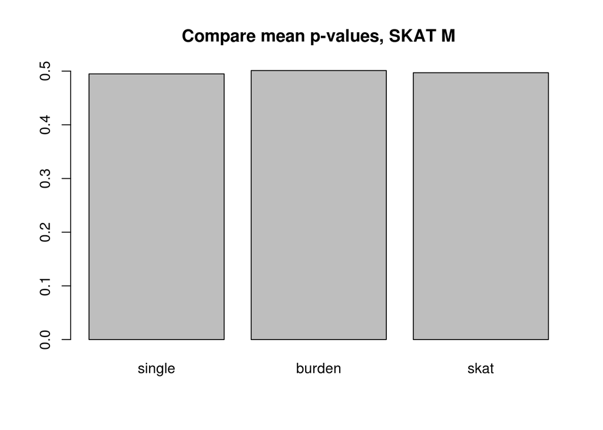

```r
# svt vs burden vs skat
mean_p_values <-
  c(mean(genes_aggr_skat.df$svt_p, na.rm=TRUE),
    mean(genes_aggr_skat.df$burden_p, na.rm=TRUE),
    mean(genes_aggr_skat.df$skat_p, na.rm=TRUE))
names(mean_p_values) <- c("single", "burden", "skat")
barplot(mean_p_values, main="Compare mean p-values, SKAT M")
```

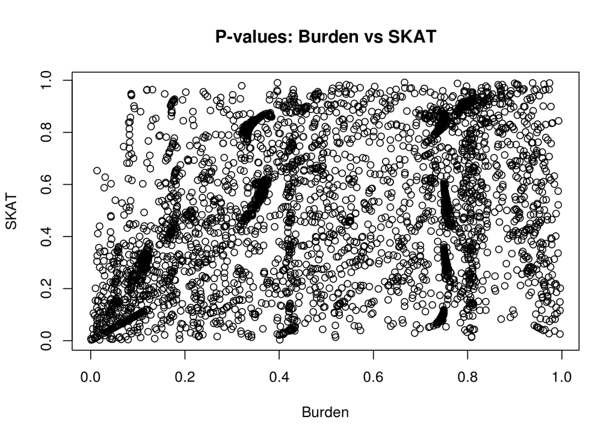

```r
# burden vs skat
plot(genes_aggr_skat.df$burden_p,
     genes_aggr_skat.df$skat_p,
     main="P-values: Burden vs SKAT",
     xlab="Burden", ylab="SKAT")
```

```r
cor.test(genes_aggr_skat.df$burden_p,
         genes_aggr_skat.df$skat_p)
```

```
##
##  Pearson's product-moment correlation
##
## data:  genes_aggr_skat.df$burden_p and genes_aggr_skat.df$skat_p
## t = 20.941, df = 4028, p-value < 2.2e-16
## alternative hypothesis: true correlation is not equal to 0
## 95 percent confidence interval:
##  0.2852243 0.3409183
## sample estimates:
##       cor
## 0.3133407
```

```r
# Clean-up
rm(mean_p_values)
```

# qq_plots

Remove NAs because they may interfere with the QQ plots

```r
# ----- svt only ----- #

# Remove NAs
svt_p <- genes_aggr_skat.df$svt_p[!is.na(genes_aggr_skat.df$svt_p)]
length(svt_p) # 4,619
```

```
## [1] 4619
```

```r
summary(svt_p)
```

```
##     Min.  1st Qu.   Median     Mean  3rd Qu.     Max.
## 0.002761 0.223144 0.650660 0.494819 0.722604 0.936411
```

```r
svt_map <- genes_aggr_skat.df$svt_map[!is.na(genes_aggr_skat.df$svt_map)]
length(svt_map) # 4,619
```

```
## [1] 4619
```

```r
summary(svt_map)
```

```
##    Min. 1st Qu.  Median    Mean 3rd Qu.    Max.
## -1.0000  0.1037  0.2065  0.1358  0.2232  0.2493
```

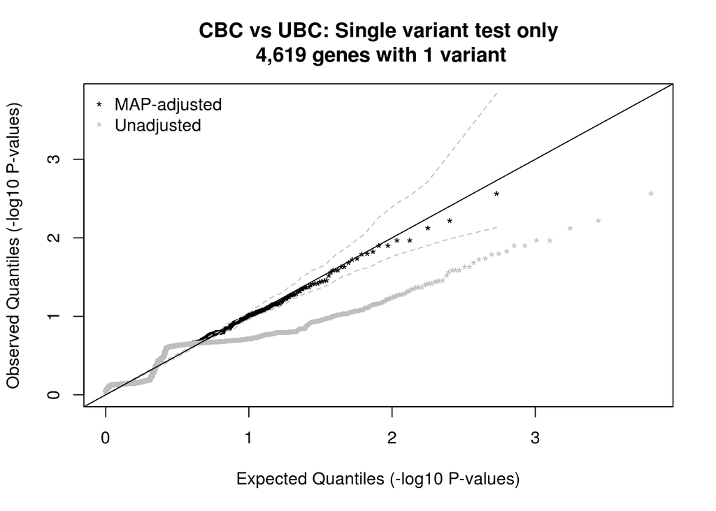

```r
# QQ plot with unadjusted
QQPlot_Adj(svt_p, svt_map,
           main=paste("CBC vs UBC: Single variant test only\n",
                      format(length(svt_p), big.mark=","),
                      "genes with 1 variant"))
```

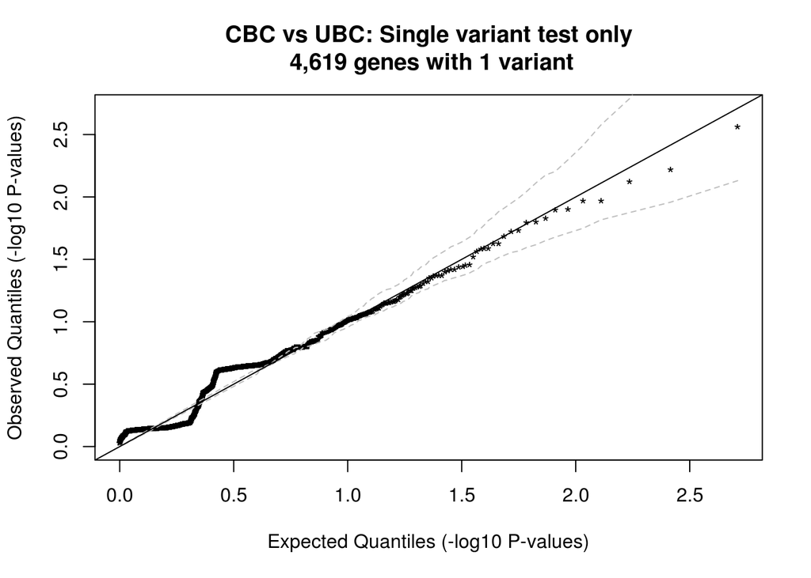

```r
# QQ plot without unadjusted
QQPlot_Adj(svt_p, svt_map, Is.unadjsted=FALSE,
           main=paste("CBC vs UBC: Single variant test only\n",
                      format(length(svt_p), big.mark=","),
                      "genes with 1 variant"))
```

```r
# ----- burden only ----- #

# Remove NAs
burden_p <- genes_aggr_skat.df$burden_p[!is.na(genes_aggr_skat.df$burden_p)]
length(burden_p) # 4,030
```

```
## [1] 4030
```

```r
summary(burden_p)
```

```
##     Min.  1st Qu.   Median     Mean  3rd Qu.     Max.
## 0.000525 0.259243 0.480346 0.501086 0.752054 0.996537
```

```r
burden_map <- genes_aggr_skat.df$burden_map[!is.na(genes_aggr_skat.df$burden_map)]
length(burden_map) # 4,030
```

```
## [1] 4030
```

```r
summary(burden_map)
```

```
##       Min.    1st Qu.     Median       Mean    3rd Qu.       Max.
## -1.0000000  0.0004978  0.0217976 -0.0590512  0.0753297  0.2433079
```

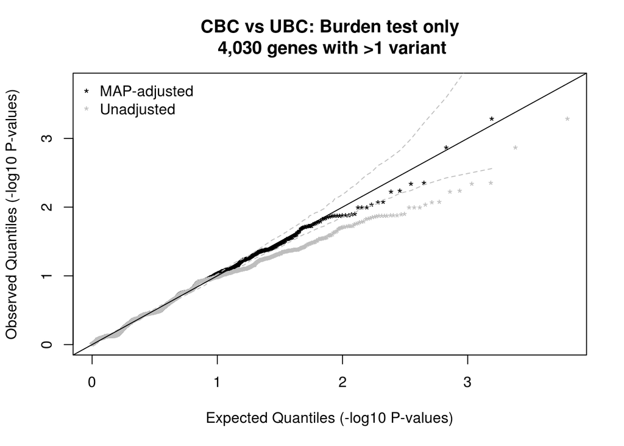

```r
# QQ plot with unadjusted
QQPlot_Adj(burden_p, burden_map,
           main=paste("CBC vs UBC: Burden test only\n",
                      format(length(burden_p), big.mark=","),
                      "genes with >1 variant"))
```

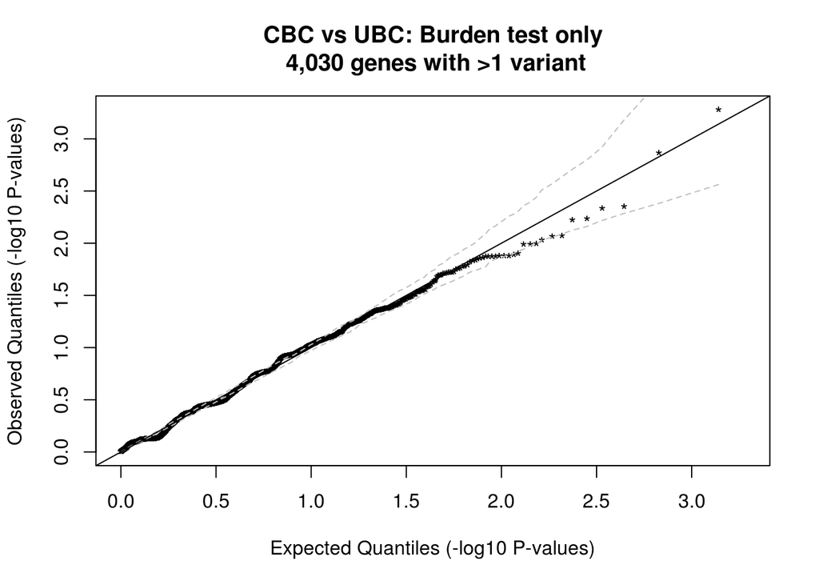

```r
# QQ plot without unadjusted
QQPlot_Adj(burden_p, burden_map, Is.unadjsted=FALSE,
           main=paste("CBC vs UBC: Burden test only\n",
                      format(length(burden_p), big.mark=","),
                      "genes with >1 variant"))
```

```r
# ----- skat only ----- #

# Remove NAs
skat_p <- genes_aggr_skat.df$skat_p[!is.na(genes_aggr_skat.df$skat_p)]
length(skat_p) # 4,030
```

```
## [1] 4030
```

```r
summary(skat_p)
```

```
##     Min.  1st Qu.   Median     Mean  3rd Qu.     Max.
## 0.002869 0.257066 0.489633 0.496972 0.782912 0.991684
```

```r
skat_map <- genes_aggr_skat.df$skat_map[!is.na(genes_aggr_skat.df$skat_map)]
length(skat_map) # 4,030
```

```
## [1] 4030
```

```r
summary(skat_map)
```

```
##       Min.    1st Qu.     Median       Mean    3rd Qu.       Max.
## -1.0000000  0.0003893  0.0173455 -0.0632024  0.0672632  0.2433079
```

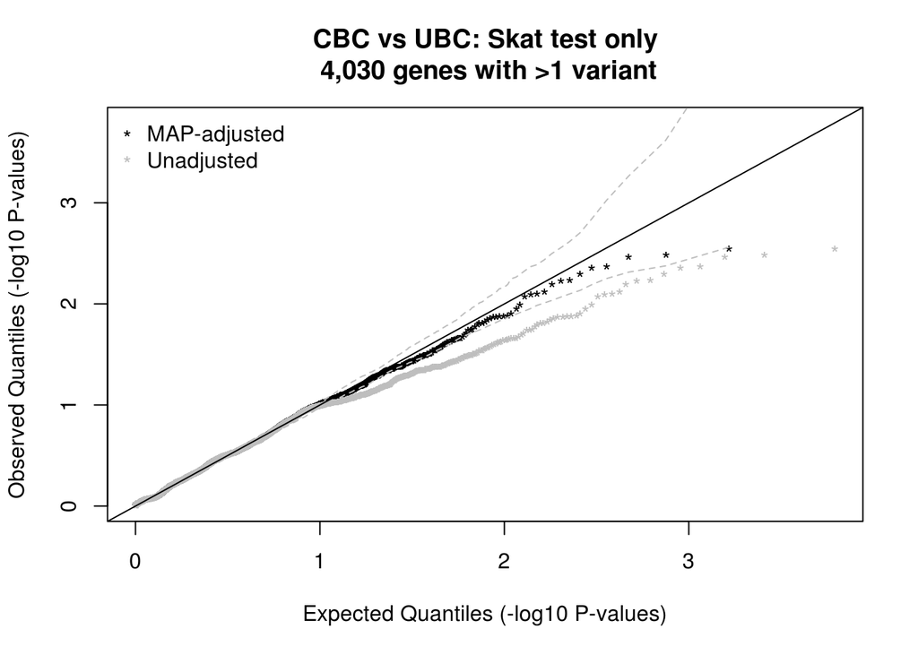

```r
# QQ plot with unadjusted
QQPlot_Adj(skat_p, skat_map,
           main=paste("CBC vs UBC: Skat test only\n",
                      format(length(skat_p), big.mark=","),
                      "genes with >1 variant"))
```

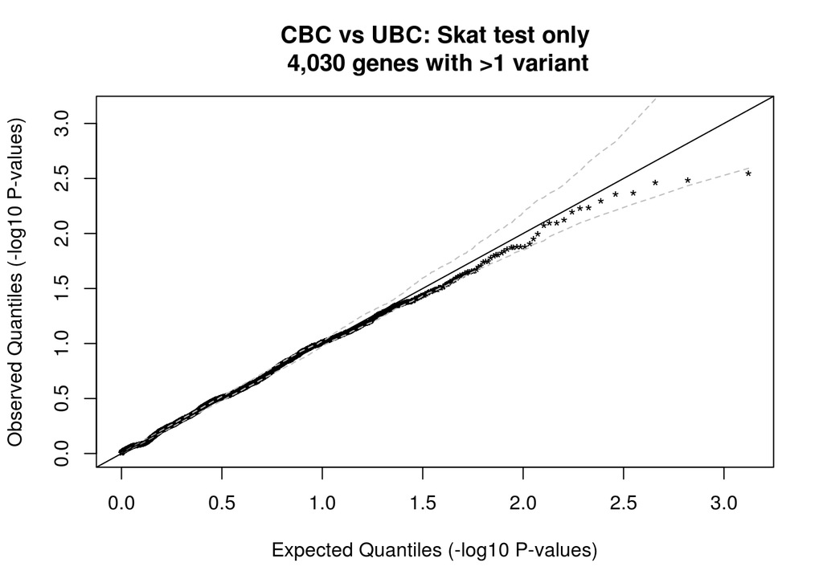

```r
# QQ plot without unadjusted
QQPlot_Adj(skat_p, skat_map, Is.unadjsted=FALSE,
           main=paste("CBC vs UBC: Skat test only\n",
                      format(length(skat_p), big.mark=","),
                      "genes with >1 variant"))
```

```r
# ----- combined svt-burden ----- #

# Check absence of NAs
svt_burden_p <- genes_aggr_skat.df$svt_burden_p
sum(is.na(svt_burden_p)) # 0
```

```
## [1] 0
```

```r
length(svt_burden_p) # 8,649
```

```
## [1] 8649
```

```r
summary(svt_burden_p)
```

```
##     Min.  1st Qu.   Median     Mean  3rd Qu.     Max.
## 0.000525 0.226702 0.538659 0.497739 0.736339 0.996537
```

```r
svt_burden_map <- genes_aggr_skat.df$svt_burden_map
sum(is.na(svt_burden_map)) # 0
```

```
## [1] 0
```

```r
length(svt_burden_map) # 8,649
```

```
## [1] 8649
```

```r
summary(svt_burden_map)
```

```
##      Min.   1st Qu.    Median      Mean   3rd Qu.      Max.
## -1.000000  0.009941  0.092819  0.045019  0.210504  0.249307
```

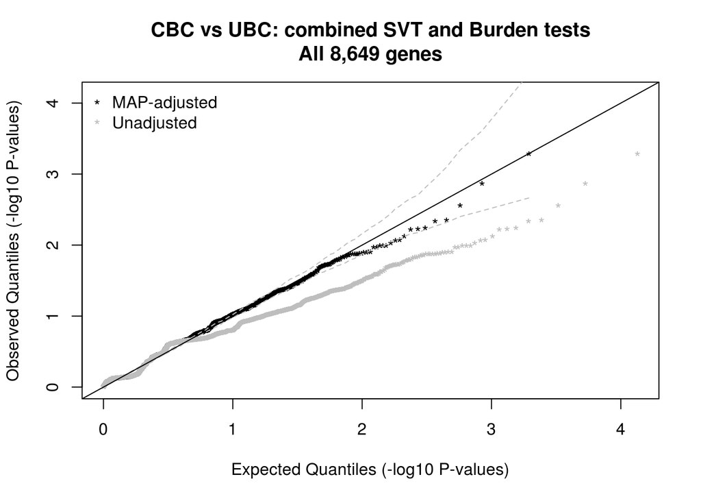

```r
# QQ plot with unadjusted
QQPlot_Adj(svt_burden_p, svt_burden_map,
           main=paste("CBC vs UBC: combined SVT and Burden tests\nAll",
                      format(length(svt_burden_p), big.mark=","), "genes"))
```

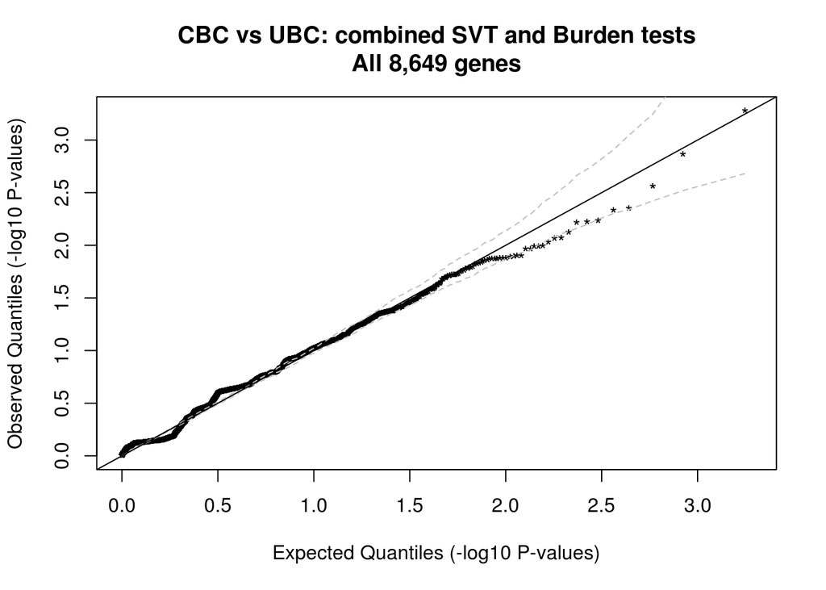

```r
# QQ plot without unadjusted
QQPlot_Adj(svt_burden_p, svt_burden_map, Is.unadjsted=FALSE,
           main=paste("CBC vs UBC: combined SVT and Burden tests\nAll",
                      format(length(svt_burden_p), big.mark=","), "genes"))
```

```r
# ----- combined svt-skat ----- #

# Check absence of NAs
svt_skat_p <- genes_aggr_skat.df$svt_skat_p
sum(is.na(svt_skat_p)) # 0
```

```
## [1] 0
```

```r
length(svt_skat_p) # 8,649
```

```
## [1] 8649
```

```r
summary(svt_skat_p)
```

```
##     Min.  1st Qu.   Median     Mean  3rd Qu.     Max.
## 0.002761 0.227680 0.532625 0.495822 0.727689 0.991684
```

```r
svt_skat_map <- genes_aggr_skat.df$svt_skat_map
sum(is.na(svt_skat_map)) # 0
```

```
## [1] 0
```

```r
length(svt_skat_map) # 8,649
```

```
## [1] 8649
```

```r
summary(svt_skat_map)
```

```
##      Min.   1st Qu.    Median      Mean   3rd Qu.      Max.
## -1.000000  0.008023  0.087664  0.043084  0.210504  0.249307
```

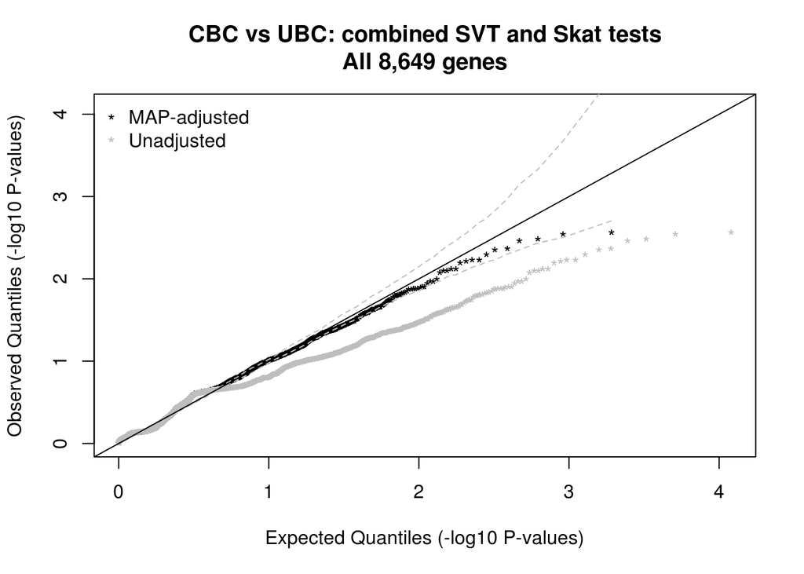

```r
# QQ plot with unadjusted
QQPlot_Adj(svt_skat_p, svt_skat_map,
           main=paste("CBC vs UBC: combined SVT and Skat tests\nAll",
                      format(length(svt_skat_p), big.mark=","), "genes"))
```

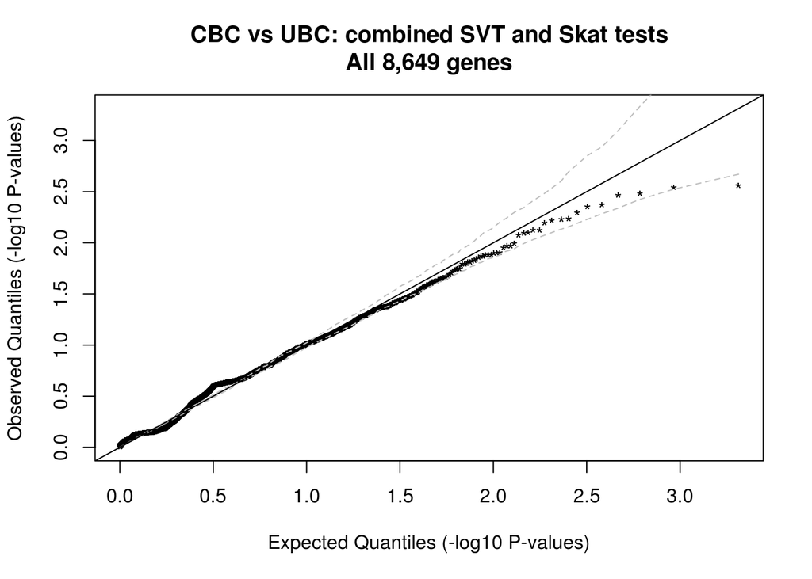

```r
# QQ plot without unadjusted
QQPlot_Adj(svt_skat_p, svt_skat_map, Is.unadjsted=FALSE,
           main=paste("CBC vs UBC: combined SVT and Skat tests\nAll",
                      format(length(svt_skat_p), big.mark=","), "genes"))
```

```r
# --- Clean-up --- #

rm(svt_p, svt_map, burden_p, burden_map, skat_p, skat_map, svt_burden_p, svt_burden_map)
```

# data_summary

```r
dim(genotypes.mx)
```

```
## [1] 16809   478
```

```r
class(genotypes.mx)
```

```
## [1] "matrix"
```

```r
genotypes.mx[1:5,1:5]
```

```
##              P1_A01 P1_A02 P1_A03 P1_A04 P1_A05
## Var000000026      0     NA      0      0      0
## Var000000029      0      0      0      0      0
## Var000000031      0      0      0      0      0
## Var000000053      0      0      0      0     NA
## Var000000064      0      0      0      0     NA
```

```r
dim(kgen.df)
```

```
## [1] 16809     9
```

```r
colnames(kgen.df)
```

```
## [1] "SplitVarID"  "kgen.AC"     "kgen.AN"     "kgen.AF"     "kgen.AFR_AF"
## [6] "kgen.AMR_AF" "kgen.EAS_AF" "kgen.EUR_AF" "kgen.SAS_AF"
```

```r
kgen.df[1:5,1:5]
```

```
##                SplitVarID kgen.AC kgen.AN     kgen.AF kgen.AFR_AF
## Var000000026 Var000000026      NA      NA          NA          NA
## Var000000029 Var000000029       1    5008 0.000199681           0
## Var000000031 Var000000031       1    5008 0.000199681           0
## Var000000053 Var000000053      NA      NA          NA          NA
## Var000000064 Var000000064      NA      NA          NA          NA
```

```r
dim(exac.df)
```

```
## [1] 16809    48
```

```r
colnames(exac.df)
```

```
##  [1] "SplitVarID"              "exac_non_TCGA.AF"
##  [3] "exac_non_TCGA.AC"        "exac_non_TCGA.AN"
##  [5] "exac_non_TCGA.AC_FEMALE" "exac_non_TCGA.AN_FEMALE"
##  [7] "exac_non_TCGA.AC_MALE"   "exac_non_TCGA.AN_MALE"
##  [9] "exac_non_TCGA.AC_Adj"    "exac_non_TCGA.AN_Adj"
## [11] "exac_non_TCGA.AC_Hom"    "exac_non_TCGA.AC_Het"
## [13] "exac_non_TCGA.AC_Hemi"   "exac_non_TCGA.AC_AFR"
## [15] "exac_non_TCGA.AN_AFR"    "exac_non_TCGA.Hom_AFR"
## [17] "exac_non_TCGA.Het_AFR"   "exac_non_TCGA.Hemi_AFR"
## [19] "exac_non_TCGA.AC_AMR"    "exac_non_TCGA.AN_AMR"
## [21] "exac_non_TCGA.Hom_AMR"   "exac_non_TCGA.Het_AMR"
## [23] "exac_non_TCGA.Hemi_AMR"  "exac_non_TCGA.AC_EAS"
## [25] "exac_non_TCGA.AN_EAS"    "exac_non_TCGA.Hom_EAS"
## [27] "exac_non_TCGA.Het_EAS"   "exac_non_TCGA.Hemi_EAS"
## [29] "exac_non_TCGA.AC_FIN"    "exac_non_TCGA.AN_FIN"
## [31] "exac_non_TCGA.Hom_FIN"   "exac_non_TCGA.Het_FIN"
## [33] "exac_non_TCGA.Hemi_FIN"  "exac_non_TCGA.AC_NFE"
## [35] "exac_non_TCGA.AN_NFE"    "exac_non_TCGA.Hom_NFE"
## [37] "exac_non_TCGA.Het_NFE"   "exac_non_TCGA.Hemi_NFE"
## [39] "exac_non_TCGA.AC_SAS"    "exac_non_TCGA.AN_SAS"
## [41] "exac_non_TCGA.Hom_SAS"   "exac_non_TCGA.Het_SAS"
## [43] "exac_non_TCGA.Hemi_SAS"  "exac_non_TCGA.AC_OTH"
## [45] "exac_non_TCGA.AN_OTH"    "exac_non_TCGA.Hom_OTH"
## [47] "exac_non_TCGA.Het_OTH"   "exac_non_TCGA.Hemi_OTH"
```

```r
exac.df[1:5,1:5]
```

```
##                SplitVarID exac_non_TCGA.AF exac_non_TCGA.AC
## Var000000026 Var000000026               NA               NA
## Var000000029 Var000000029        1.506e-04               16
## Var000000031 Var000000031        2.354e-04               25
## Var000000053 Var000000053        1.883e-05                2
## Var000000064 Var000000064        9.416e-06                1
##              exac_non_TCGA.AN exac_non_TCGA.AC_FEMALE
## Var000000026               NA                      NA
## Var000000029           106210                       8
## Var000000031           106210                       4
## Var000000053           106210                       0
## Var000000064           106206                       0
```

```r
dim(variants.df)
```

```
## [1] 16809    45
```

```r
str(variants.df)
```

```
## 'data.frame':    16809 obs. of  45 variables:
##  $ SplitVarID        : Factor w/ 343824 levels "Var000000001",..: 26 29 31 53 64 227 237 300 413 430 ...
##  $ SYMBOL            : Factor w/ 19862 levels "A1BG","A1CF",..: 11149 11149 11149 8665 8665 540 540 18233 3808 6597 ...
##  $ TYPE              : Factor w/ 2 levels "INDEL","SNP": 2 2 2 2 2 2 2 2 2 2 ...
##  $ CHROM             : Factor w/ 25 levels "1","10","11",..: 1 1 1 1 1 1 1 1 1 1 ...
##  $ POS               : int  881871 883883 883946 897287 897792 987173 989899 1132513 1249141 1262635 ...
##  $ REF               : Factor w/ 2142 levels "A","AAAAAAAAAAAAAAAAAAAAAAAG",..: 1044 1575 539 539 539 1575 539 539 1044 1575 ...
##  $ ALT               : Factor w/ 1297 levels "A","AAAAAAAAAAAAACT",..: 1 323 989 989 989 664 989 989 1 1 ...
##  $ ac_raw            : int  1 2 1 1 1 1 1 2 1 1 ...
##  $ af_raw            : num  0.000711 0.001555 0.000774 0.000711 0.000722 ...
##  $ an_raw            : int  1406 1286 1292 1406 1386 1420 1414 1320 1378 1380 ...
##  $ Consequence       : Factor w/ 78 levels "3_prime_UTR_variant",..: 66 28 28 28 66 28 28 28 28 28 ...
##  $ SIFT_call         : Factor w/ 4 levels "deleterious",..: NA 1 1 1 NA 1 1 1 1 1 ...
##  $ SIFT_score        : num  NA 0 0.01 0.04 NA 0 0.02 0.02 0 0 ...
##  $ PolyPhen_call     : Factor w/ 4 levels "benign","possibly_damaging",..: NA 3 3 3 NA 3 3 3 3 3 ...
```

[output cut: 31 more lines]

```r
variants.df[1:5,1:5]
```

```
##                SplitVarID SYMBOL TYPE CHROM    POS
## Var000000026 Var000000026  NOC2L  SNP     1 881871
## Var000000029 Var000000029  NOC2L  SNP     1 883883
## Var000000031 Var000000031  NOC2L  SNP     1 883946
## Var000000053 Var000000053 KLHL17  SNP     1 897287
## Var000000064 Var000000064 KLHL17  SNP     1 897792
```

```r
dim(phenotypes.df)
```

```
## [1] 478  36
```

```r
str(phenotypes.df)
```

```
## 'data.frame':    478 obs. of  36 variables:
##  $ wes_id        : chr  "P1_A01" "P1_A02" "P1_A03" "P1_A04" ...
##  $ gwas_id       : chr  "id203568" "id357807" "id325472" "id304354" ...
##  $ merged_id     : chr  "P1_A01_id203568" "P1_A02_id357807" "P1_A03_id325472" "P1_A04_id304354" ...
##  $ filter        : chr  "pass" "pass" "pass" "pass" ...
##  $ cc            : int  1 1 1 1 1 1 0 1 1 0 ...
##  $ setno         : int  203568 357807 325472 304354 222648 244843 276284 297810 250898 226974 ...
##  $ registry      : Factor w/ 5 levels "de","IA","IR",..: 3 4 2 2 5 4 2 4 4 2 ...
##  $ family_history: int  1 0 1 1 1 1 1 1 1 0 ...
##  $ age_dx        : int  49 35 32 33 44 28 28 38 35 36 ...
##  $ age_ref       : num  58 36 41 34 49 28 32 44 35 38 ...
##  $ rstime        : num  10.17 1.83 9.75 1.59 5.66 ...
##  $ eig1_gwas     : num  -0.00389 -0.00379 -0.01011 -0.01288 -0.01086 ...
##  $ eig2_gwas     : num  0.00266 0.00246 -0.0001 0.00595 0.01157 ...
##  $ eig3_gwas     : num  0.06803 0.05055 -0.00603 0.00747 0.00144 ...
```

[output cut: 22 more lines]

```r
phenotypes.df[1:5,1:5]
```

```
##        wes_id  gwas_id       merged_id filter cc
## P1_A01 P1_A01 id203568 P1_A01_id203568   pass  1
## P1_A02 P1_A02 id357807 P1_A02_id357807   pass  1
## P1_A03 P1_A03 id325472 P1_A03_id325472   pass  1
## P1_A04 P1_A04 id304354 P1_A04_id304354   pass  1
## P1_A05 P1_A05 id222648 P1_A05_id222648   pass  1
```

```r
dim(genotypes_inv.mx)
```

```
## [1] 16809   478
```

```r
class(genotypes_inv.mx)
```

```
## [1] "matrix"
```

```r
genotypes_inv.mx[1:5,1:5]
```

```
##              P1_A01 P1_A02 P1_A03 P1_A04 P1_A05
## Var000000026      0     NA      0      0      0
## Var000000029      0      0      0      0      0
## Var000000031      0      0      0      0      0
## Var000000053      0      0      0      0     NA
## Var000000064      0      0      0      0     NA
```

```r
dim(variants_inv.df)
```

```
## [1] 16809    67
```

```r
str(variants_inv.df)
```

```
## 'data.frame':    16809 obs. of  67 variables:
##  $ SplitVarID        : Factor w/ 343824 levels "Var000000001",..: 26 29 31 53 64 227 237 300 413 430 ...
##  $ SYMBOL            : Factor w/ 19862 levels "A1BG","A1CF",..: 11149 11149 11149 8665 8665 540 540 18233 3808 6597 ...
##  $ TYPE              : Factor w/ 2 levels "INDEL","SNP": 2 2 2 2 2 2 2 2 2 2 ...
##  $ CHROM             : Factor w/ 25 levels "1","10","11",..: 1 1 1 1 1 1 1 1 1 1 ...
##  $ POS               : int  881871 883883 883946 897287 897792 987173 989899 1132513 1249141 1262635 ...
##  $ REF               : Factor w/ 2142 levels "A","AAAAAAAAAAAAAAAAAAAAAAAG",..: 1044 1575 539 539 539 1575 539 539 1044 1575 ...
##  $ ALT               : Factor w/ 1297 levels "A","AAAAAAAAAAAAACT",..: 1 323 989 989 989 664 989 989 1 1 ...
##  $ ac_raw            : int  1 2 1 1 1 1 1 2 1 1 ...
##  $ af_raw            : num  0.000711 0.001555 0.000774 0.000711 0.000722 ...
##  $ an_raw            : int  1406 1286 1292 1406 1386 1420 1414 1320 1378 1380 ...
##  $ Consequence       : Factor w/ 78 levels "3_prime_UTR_variant",..: 66 28 28 28 66 28 28 28 28 28 ...
##  $ SIFT_call         : Factor w/ 4 levels "deleterious",..: NA 1 1 1 NA 1 1 1 1 1 ...
##  $ SIFT_score        : num  NA 0 0.01 0.04 NA 0 0.02 0.02 0 0 ...
##  $ PolyPhen_call     : Factor w/ 4 levels "benign","possibly_damaging",..: NA 3 3 3 NA 3 3 3 3 3 ...
```

[output cut: 53 more lines]

```r
variants_inv.df[1:5,1:5]
```

```
##                SplitVarID SYMBOL TYPE CHROM    POS
## Var000000026 Var000000026  NOC2L  SNP     1 881871
## Var000000029 Var000000029  NOC2L  SNP     1 883883
## Var000000031 Var000000031  NOC2L  SNP     1 883946
## Var000000053 Var000000053 KLHL17  SNP     1 897287
## Var000000064 Var000000064 KLHL17  SNP     1 897792
```

```r
dim(genes_inv_aggr_data.mx)
```

```
## [1] 8649  478
```

```r
class(genes_inv_aggr_data.mx)
```

```
## [1] "matrix"
```

```r
genes_inv_aggr_data.mx[1:5,1:5]
```

```
##        P1_A01 P1_A02 P1_A03 P1_A04 P1_A05
## NOC2L       0      0      0      0      0
## KLHL17      0      0      0      0      0
## AGRN        0      0      0      0      0
## TTLL10      0      0      0      0      0
## CPSF3L      0      0      0      0      0
```

```r
dim(genes_inv_aggr_info.df)
```

```
## [1] 8649   27
```

```r
str(genes_inv_aggr_info.df)
```

```
## 'data.frame':    8649 obs. of  27 variables:
##  $ gene             : chr  "NOC2L" "KLHL17" "AGRN" "TTLL10" ...
##  $ num_var          : num  3 2 2 1 1 1 1 2 1 1 ...
##  $ inverted         : logi  FALSE FALSE FALSE FALSE FALSE FALSE ...
##  $ multiallelic     : logi  FALSE FALSE FALSE FALSE FALSE FALSE ...
##  $ aggr_ac          : num  4 2 2 2 1 1 41 3 1 1 ...
##  $ aggr_an          : num  956 956 956 956 956 956 956 956 956 956 ...
##  $ aggr_af          : num  0.00418 0.00209 0.00209 0.00209 0.00105 ...
##  $ aggr_ac_cbc      : num  3 2 1 2 1 1 20 2 0 1 ...
##  $ aggr_an_cbc      : num  466 466 466 466 466 466 466 466 466 466 ...
##  $ aggr_af_cbc      : num  0.00644 0.00429 0.00215 0.00429 0.00215 ...
##  $ aggr_ac_ubc      : num  1 0 1 0 0 0 21 1 1 0 ...
##  $ aggr_an_ubc      : num  490 490 490 490 490 490 490 490 490 490 ...
##  $ aggr_af_ubc      : num  0.00204 0 0.00204 0 0 ...
##  $ aggr_ac_cbc_fam  : num  1 0 0 2 0 1 9 0 0 0 ...
##  $ aggr_an_cbc_fam  : num  166 166 166 166 166 166 166 166 166 166 ...
##  $ aggr_af_cbc_fam  : num  0.00602 0 0 0.01205 0 ...
##  $ aggr_ac_cbc_nofam: num  2 2 1 0 1 0 11 2 0 1 ...
##  $ aggr_an_cbc_nofam: num  300 300 300 300 300 300 300 300 300 300 ...
##  $ aggr_af_cbc_nofam: num  0.00667 0.00667 0.00333 0 0.00333 ...
##  $ aggr_ac_ubc_fam  : num  0 0 0 0 0 0 8 0 1 0 ...
##  $ aggr_an_ubc_fam  : num  142 142 142 142 142 142 142 142 142 142 ...
##  $ aggr_af_ubc_fam  : num  0 0 0 0 0 ...
##  $ aggr_ac_ubc_nofam: num  1 0 1 0 0 0 13 1 0 0 ...
##  $ aggr_an_ubc_nofam: num  348 348 348 348 348 348 348 348 348 348 ...
##  $ aggr_af_ubc_nofam: num  0.00287 0 0.00287 0 0 ...
##  $ cbc_ubc_call     : Factor w/ 2 levels "protective","risk": 2 2 2 2 2 2 2 2 1 2 ...
##  $ cbc_ubc_fisher_p : num  0.362 0.237 1 0.237 0.487 ...
```

```r
genes_inv_aggr_info.df[1:5,1:5]
```

```
##          gene num_var inverted multiallelic aggr_ac
## NOC2L   NOC2L       3    FALSE        FALSE       4
## KLHL17 KLHL17       2    FALSE        FALSE       2
## AGRN     AGRN       2    FALSE        FALSE       2
## TTLL10 TTLL10       1    FALSE        FALSE       2
## CPSF3L CPSF3L       1    FALSE        FALSE       1
```

```r
dim(genes_aggr_skat.df)
```

```
## [1] 8649   12
```

```r
str(genes_aggr_skat.df)
```

```
## 'data.frame':    8649 obs. of  12 variables:
##  $ gene          : chr  "NOC2L" "KLHL17" "AGRN" "TTLL10" ...
##  $ num_var       : int  3 2 2 1 1 1 1 2 1 1 ...
##  $ svt_p         : num  NA NA NA 0.346 0.731 ...
##  $ svt_map       : num  NA NA NA 0.0916 0.2311 ...
##  $ burden_p      : num  0.533 0.343 0.751 NA NA ...
##  $ burden_map    : num  0.0136 0.0873 0.1056 NA NA ...
##  $ skat_p        : num  0.465 0.831 0.575 NA NA ...
##  $ skat_map      : num  0.0119 0.0873 0.1056 NA NA ...
##  $ svt_burden_p  : num  0.533 0.343 0.751 0.346 0.731 ...
##  $ svt_burden_map: num  0.0136 0.0873 0.1056 0.0916 0.2311 ...
##  $ svt_skat_p    : num  0.465 0.831 0.575 0.346 0.731 ...
##  $ svt_skat_map  : num  0.0119 0.0873 0.1056 0.0916 0.2311 ...
```

```r
genes_aggr_skat.df[1:5,1:5]
```

```
##          gene num_var     svt_p    svt_map  burden_p
## NOC2L   NOC2L       3        NA         NA 0.5332056
## KLHL17 KLHL17       2        NA         NA 0.3434846
## AGRN     AGRN       2        NA         NA 0.7510745
## TTLL10 TTLL10       1 0.3462244 0.09164592        NA
## CPSF3L CPSF3L       1 0.7311126 0.23111256        NA
```

```r
# Check consistency of rownames and colnames
sum(colnames(genotypes.mx) != rownames(phenotypes.df))
```

```
## [1] 0
```

```r
sum(rownames(genotypes.mx) != rownames(kgen.df))
```

```
## [1] 0
```

```r
sum(rownames(genotypes.mx) != rownames(exac.df))
```

```
## [1] 0
```

```r
sum(rownames(genotypes.mx) != rownames(variants.df))
```

```
## [1] 0
```

```r
sum(colnames(genes_inv_aggr_data.mx) != rownames(phenotypes.df))
```

```
## [1] 0
```

```r
sum(rownames(genes_inv_aggr_info.df) != rownames(genes_inv_aggr_data.mx))
```

```
## [1] 0
```

```r
sum(rownames(genes_inv_aggr_data.mx) != rownames(genes_aggr_skat.df))
```

```
## [1] 0
```

# save_results

```r
#base_folder="/analysis/mtgroup_share/users/alexey/wecare_only_08.17"
save.image(paste(base_folder, "results", "r09_skat_wecare_only.RData", sep="/"))
```

# final_section

```r
ls()
```

```
##  [1] "base_folder"            "exac.df"
##  [3] "genes_aggr_skat.df"     "genes_inv_aggr_data.mx"
##  [5] "genes_inv_aggr_info.df" "genotypes_inv.mx"
##  [7] "genotypes.mx"           "kgen.df"
##  [9] "phenotypes.df"          "svt_skat_map"
## [11] "svt_skat_p"             "variants.df"
## [13] "variants_inv.df"
```

```r
Sys.time()
```

```
## [1] "2017-08-30 17:07:39 BST"
```